# Analysis of traffic at the intersections around Fullarton and Glen Osmond Roads

Ben Moretti

07/06/2021

# Introduction

This notebook analyses some data from the intersections around Fullarton / Glen Osmond Road in Adelaide, South Australia.

# Data

Data is derived from the South Australian Government data portal

https://data.sa.gov.au/data/dataset/traffic-volumes-on-top-40-intersections-in-sa

“A ranking of the top 40 intersections based on the number of vehicles passing through each intersection.”

Data were downloaded in CSV format to a subdirectory, as follows

```r
fs::dir_ls("../data/")
```

```
## ../data/top-40-at-grade-arterial-road-intersections-for-all-vehicles-2017.csv
## ../data/top-40-at-grade-arterial-road-intersections-for-all-vehicles-2018.csv
## ../data/top-40-at-grade-arterial-road-intersections-for-all-vehicles-2019.csv
## ../data/top-40-at-grade-arterial-road-intersections-for-all-vehicles-2020.csv
```

Each file has the following metadata as defined

- Rank - Relative importance
- Location - Description of the intersecting roads
- Vehicle Exposure - "A measure of traffic volumes passing through intersections. It is calculated by adding the estimated Annual Average Daily Traffic (est. AADT) volumes on all arms of the intersection and dividing the result by two. Vehicle Exposure estimates are based on data obtained from the most recent single day 11 hour manual turning count surveys conducted at the intersections.

# Analysis

## Data Gathering

First, the data are read from CSV and have the recorded year appended

```r
# All of the data have been downloaded to the data directory from the repository above

# 2017 data
data_2017_tbl <- read_csv(file = "../data/top-40-at-grade-arterial-road-intersections-for-all-vehicles-2017.csv", skip=2) %>%
  clean_names() %>%
  mutate(
    recorded_year = 2017
  )
# 2018 data
data_2018_tbl <- read_csv(file = "../data/top-40-at-grade-arterial-road-intersections-for-all-vehicles-2018.csv", skip=2) %>%
  clean_names() %>%
  mutate(
    recorded_year = 2018
  )
# 2019 data
data_2019_tbl <- read_csv(file = "../data/top-40-at-grade-arterial-road-intersections-for-all-vehicles-2019.csv", skip=2) %>%
  clean_names() %>%
  mutate(
    recorded_year = 2019
  )
# 2020 data
data_2020_tbl <- read_csv(file = "../data/top-40-at-grade-arterial-road-intersections-for-all-vehicles-2020.csv", skip=2) %>%
  clean_names() %>%
  mutate(
    recorded_year = 2020
  )
```

## Tidy

Once read the data are combined into a single data frame

```r
# combine the data into a single data frame
data_combined_tbl <- bind_rows(data_2017_tbl,
                               data_2018_tbl,
                               data_2019_tbl,
                               data_2020_tbl)
```

## Explore

The data structure can be reviewed here

```r
# data frame structure
data_combined_tbl %>% glimpse()
```

```
## Rows: 160
## Columns: 4
## $ rank             <dbl> 1, 2, 3, 4, 5, 6, 7, 8, 9, 10, 11, 12, 13, 14, 15, 16…
## $ location         <chr> "PORT WAKEFIELD ROAD / SALISBURY HIGHWAY", "MAIN SOUT…
## $ vehicle_exposure <dbl> 113500, 98400, 91700, 91400, 87900, 84300, 81900, 806…
## $ recorded_year    <dbl> 2017, 2017, 2017, 2017, 2017, 2017, 2017, 2017, 2017,…
```

Look at the distinct names for the locations

```r
data_combined_tbl %>%
  distinct(location) %>%
  arrange(location) %>%
  kbl() %>%
  kable_styling()
```

| location |
| --- |
| ADAM STREET / PARK TERRACE / PORT ROAD |
| ANZAC HIGHWAY / GOODWOOD ROAD / SOUTH TERRACE / WEST TERRACE |
| ANZAC HIGHWAY / GREENHILL ROAD / RICHMOND ROAD |
| ANZAC HIGHWAY / MARION ROAD |
| ANZAC HIGHWAY / SOUTH ROAD |
| ASHWIN PARADE / SOUTH ROAD / WEST THEBARTON ROAD |
| AYLIFFES ROAD / MAIN SOUTH ROAD / SHEPHERDS HILL ROAD / SOUTH ROAD |
| BLACK TOP ROAD / MAIN NORTH ROAD |
| BOTANIC ROAD / DEQUETTEVILLE TERRACE / HACKNEY ROAD / NORTH TERRACE |
| CAVAN ROAD / CHURCHILL ROAD / GRAND JUNCTION ROAD |
| CHURCHILL ROAD NORTH / MONTAGUE ROAD / PORT WAKEFIELD ROAD |
| CROSS ROAD / GLEN OSMOND ROAD / PORTRUSH ROAD / SOUTH EASTERN FREEWAY |
| CROSS ROAD / SOUTH ROAD |
| CURRIE STREET / GLOVER AVENUE / WEST TERRACE |
| DAWS ROAD / MARION ROAD / OAKLANDS ROAD |
| DAWS ROAD / SOUTH ROAD |
| ELDER SMITH ROAD / MAIN NORTH ROAD / MAXWELL ROAD |
| ELDER SMITH ROAD / SALISBURY HIGHWAY / ELDER SMITH ROAD |
| FITZROY TERRACE / JEFFCOTT ROAD / PARK TERRACE / TORRENS ROAD |
| FITZROY TERRACE / MAIN NORTH ROAD / ROBE TERRACE |
| FLINDERS DRIVE / MAIN SOUTH ROAD |
| FULLARTON ROAD / GREENHILL ROAD |
| GEORGE STREET / JAMES CONGDON DRIVE / PORT ROAD |
| GLEN OSMOND ROAD / GREENHILL ROAD |
| GOODWOOD ROAD / GREENHILL ROAD |
| GRAND JUNCTION ROAD / MAIN NORTH ROAD / PORT WAKEFIELD ROAD |
| GRANGE ROAD / MANTON STREET / SOUTH ROAD |
| GREENHILL ROAD / KING WILLIAM ROAD / PEACOCK ROAD |
| GREENHILL ROAD / PORTRUSH ROAD |
| GREENHILL ROAD / UNLEY ROAD |
| GROTE STREET / SIR DONALD BRADMAN DRIVE / WEST TERRACE |
| HENLEY BEACH ROAD / SOUTH ROAD |
| JOHN RICE AVENUE / MAIN NORTH ROAD |
| KINGS ROAD / MAIN NORTH ROAD / MCINTYRE ROAD |
| KINGS ROAD / SALISBURY HIGHWAY |
| LOWER PORTRUSH ROAD / PAYNEHAM ROAD / PORTRUSH ROAD |
| MAIN NORTH ROAD / MONTAGUE ROAD |
| MAIN NORTH ROAD / NOTTAGE TERRACE |
| MAIN NORTH ROAD / PHILIP HIGHWAY / YORKTOWN ROAD |
| MAIN NORTH ROAD / REGENCY ROAD |
| MAIN NORTH ROAD / SAINTS ROAD / THE GROVE WAY |
| MAIN SOUTH ROAD / SOUTHERN EXPRESSWAY |
| MAIN SOUTH ROAD / STURT ROAD |
| MARION ROAD / STURT ROAD |
| MARTINS ROAD / PORT WAKEFIELD ROAD |
| NORTH EAST ROAD / SUDHOLZ ROAD |
| PHILLIPS STREET / PORT ROAD / PARKLANDS ACCESS |
| PORT ROAD / LIGHT TERRACE |
| PORT ROAD / SOUTH ROAD |
| PORT WAKEFIELD ROAD / SALISBURY HIGHWAY |
| REGENCY ROAD / SOUTH ROAD |
| RICHMOND ROAD / SOUTH ROAD |
| SIR DONALD BRADMAN DRIVE / SOUTH ROAD |

Looks like we just need the following locations

```r
data_combined_tbl %>%
  filter(str_detect(location, "GLEN OSMOND") | str_detect(location, "FULLARTON") | str_detect(location, "UNLEY") | str_detect(location, "PORTRUSH"))  %>%
  filter(! str_detect(location, "PAYNEHAM")) %>%
  distinct(location)
```

```
## # A tibble: 5 x 1
##   location
##   <chr>
## 1 GREENHILL ROAD / UNLEY ROAD
## 2 FULLARTON ROAD / GREENHILL ROAD
## 3 CROSS ROAD / GLEN OSMOND ROAD / PORTRUSH ROAD / SOUTH EASTERN FREEWAY
## 4 GLEN OSMOND ROAD / GREENHILL ROAD
## 5 GREENHILL ROAD / PORTRUSH ROAD
```

Assign the locations we want to a list

```r
location_lst <- data_combined_tbl %>%
  filter(str_detect(location, "GLEN OSMOND") | str_detect(location, "FULLARTON") | str_detect(location, "UNLEY") | str_detect(location, "PORTRUSH"))  %>%
  filter(! str_detect(location, "PAYNEHAM")) %>%
  distinct(location) %>%
  pull()
```

# Visualise

Plot out the data in time series

```r
intersections_plot <- data_combined_tbl %>%

  # convert values into thousands
  mutate(
    vehicle_exposure = vehicle_exposure / 1000
  ) %>%

  # only get the required locations
  filter(location %in% location_lst) %>%

  # clean up location so that it is a bit tidier and shorter
  mutate(
    location_text = str_remove_all(location, " ROAD"),
    location_text = str_trim(location, side="both")
  ) %>%

  # plot a line plot with points for the recorded year vs vehicle exposure with colour by location and a label of the number
  ggplot(aes(x=recorded_year, y=vehicle_exposure, colour=location_text, label=vehicle_exposure)) +
  geom_line(size=2) +
  geom_point(size=3) +
  geom_text(aes(label=vehicle_exposure),hjust=0, vjust=2) +

  # facet wrap by location
  facet_wrap(vars(location_text)) +
  ylim(0,80) +

  # theme stuff
  theme_tq() +
  scale_colour_tq() +

  # informative labels
  labs(
    title="Intersection Traffic Volumes in or around Glen Osmond Road",
    subtitle = str_glue("Derived from \"Traffic volumes on top 40 intersections in SA\".

                         Source: https://data.sa.gov.au/data/dataset/traffic-volumes-on-top-40-intersections-in-sa

                         Vehicle Exposure: A measure of traffic volumes passing through intersections. It is calculated by adding the estimated Annual Average Daily Traffic (est. AADT) volumes
                         on all arms of the intersection and dividing the result by two. Vehicle Exposure estimates are based on data obtained from the most recent single day 11 hour manual
                         turning count surveys conducted at the intersections."),
    x = "Recorded Year",
    y = "Vehicle Exposure ('000)",
    caption = "4 June 2021, Ben Moretti @morebento",
    colour = "Location"
  )
```

```
## geom_path: Each group consists of only one observation. Do you need to adjust
## the group aesthetic?
```

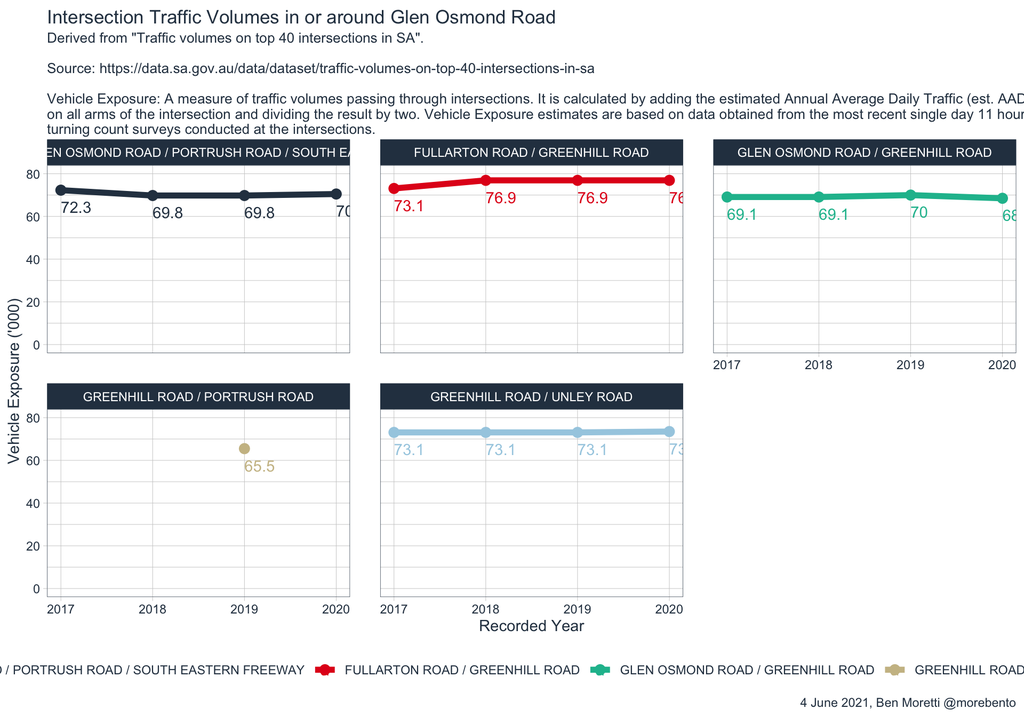

```r
intersections_plot
```

Save it as a plot

```r
ggsave(
  file = "../plots/glen_osmond_road_intersection_traffic.png",
  plot = intersections_plot,
  width = 297,
  height = 210,
  units = "mm"
)
```

```
## geom_path: Each group consists of only one observation. Do you need to adjust
## the group aesthetic?
```